# Principal Component Analysis: A Gentle Tutorial

Shobha Gupta

2025-10-16

# Overview

Throughout this guide, we’ll move step-by-step from intuition to practice. We’ll start by building a clear mental picture of what PCA does and why it’s useful. Then, we’ll bring that intuition to life using R, showing you exactly how to perform PCA with the prcomp() function and how to visualize your results in a meaningful way.

Along the way, we’ll answer questions like:

–> What does PCA really do to my data?

–> How can I tell which components are important?

–> How much information am I losing when I reduce dimensions?

–> And how do I interpret the beautiful plots that come out of it?

We’ll reinforce these ideas through hands-on examples:

Two synthetic datasets to help you see how PCA transforms data,

By the end, PCA will no longer feel like a mysterious black box — it will feel like a practical tool you can use to simplify, visualize, and understand your data.

For deeper reading and background, refer to the excellent discussions in James et al. (2013) (Chapter 10), Jolliffe (2002), and Abdi & Williams (2010).

# 1 — Intuition: what is PCA?

Imagine you’ve collected a lot of data — maybe dozens of measurements about each person in a study: their height, weight, blood pressure, cholesterol, age, and more. Each variable tells you something useful, but together they create a web of information that’s hard to untangle. Many of these variables are related — for example, taller people might weigh more, and age might be connected to blood pressure. When variables overlap like this, it becomes tricky to see the bigger picture.

Principal Component Analysis (PCA) is a technique that helps us simplify that complexity. It finds new axes — called principal components — that summarize the key patterns in the data without losing much information. These new components are combinations of the original variables, but arranged in such a way that they capture the directions where the data varies the most.

You can think of PCA as turning your data to a new angle, one where the underlying structure suddenly becomes clearer — like rotating a sculpture until you find the viewpoint that best shows its shape.

Here’s what makes PCA special:

It focuses on variability: PCA looks for directions where the data changes the most. These directions often reveal the most meaningful patterns.

It creates independent axes: Each principal component is at a right angle (orthogonal) to the others, so they don’t overlap in the information they capture.

It’s unsupervised: PCA doesn’t rely on labels or outcomes. It simply explores the structure of your data to find the most informative view.

To sum it up we can say that PCA reduces the dimensionality of data while preserving its essential structure. It turns a high-dimensional, hard-to-visualize dataset into a simpler one that still tells the same story — just from a clearer perspective (James et al. (2013)).

# 2 — Quick mathematical sketch (short)

When we collect data, each variable tells part of the story — maybe one column records a person’s height, another their weight, and another their age. If we plot all those variables together, the data might look like a scattered cloud of points. Some directions in that cloud will have more “spread” than others — maybe height and weight vary together, forming a slanted pattern. This is what PCA tries to find: the directions where the data naturally spreads out the most.

To do that, we start with something called the covariance matrix. Think of it as a summary of how every pair of variables moves together. If two features rise and fall together, their covariance is positive; if one increases while the other decreases, it’s negative. So the covariance matrix captures the relationships in the data — it tells us which features “go hand in hand.”

Now, once we have that covariance matrix, PCA looks for the main directions of movement in it — the directions where the spread is largest. Mathematically, those directions are called eigenvectors, and how much the data spreads along each one is measured by eigenvalues. You can imagine drawing arrows through the cloud of data:

The longest arrow points in the direction of the greatest variation — that’s the first principal component.

The second arrow, drawn at a right angle to the first, captures the next most important direction, and so on.

In R, we can find these arrows and their strengths by performing something called an eigen decomposition on the covariance matrix. Alternatively, we can use a technique called Singular Value Decomposition (SVD), which does the same thing in a slightly different, often faster way. Both approaches are just two paths to the same goal — finding the new set of axes that describe the data in the simplest way possible.

So, to summarize this story:

We begin with a data matrix $X$ (after centering it by subtracting the mean). We then calculate how each feature relates to the others using the covariance matrix $S = \frac{1}{n-1} X^T X$. By finding the eigenvectors and eigenvalues of $S$ (or equivalently by using SVD), we uncover the main directions of variation in the data. These directions — the principal components — capture how the data naturally spreads, helping us simplify complex data into clearer patterns (Jolliffe (2002)).

# 3 — Hands-on: Synthetic examples

## 3.1 Example 1 — Two-dimensional rotated data (visual intuition)

To start small, let’s imagine a simple dataset with just two variables that are strongly related — maybe something like a person’s height and weight.

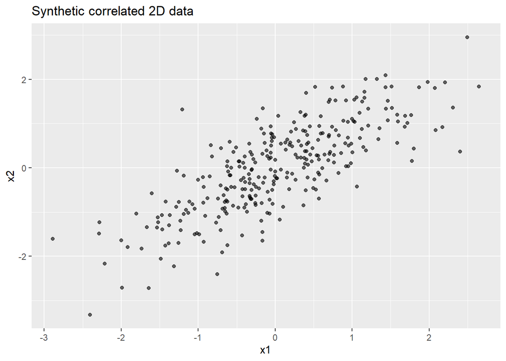

```r
set.seed(1)
n <- 300
x1 <- rnorm(n)
x2 <- 0.8*x1 + rnorm(n, sd = 0.6)
df2 <- data.frame(x1 = x1, x2 = x2)

ggplot(df2, aes(x = x1, y = x2)) + geom_point(alpha = 0.6) +
  labs(title = 'Synthetic correlated 2D data')
```

If you look at the scatterplot, you’ll notice that the points form a slanted oval shape — meaning the two variables are correlated. There’s more spread in one direction than in the other.

Let’s use PCA to discover that main direction of spread.

```r
pca2 <- prcomp(df2, center = TRUE, scale. = TRUE)
summary(pca2)
```

```
## Importance of components:
##                          PC1    PC2
## Standard deviation     1.335 0.4668
## Proportion of Variance 0.891 0.1090
## Cumulative Proportion  0.891 1.0000
```

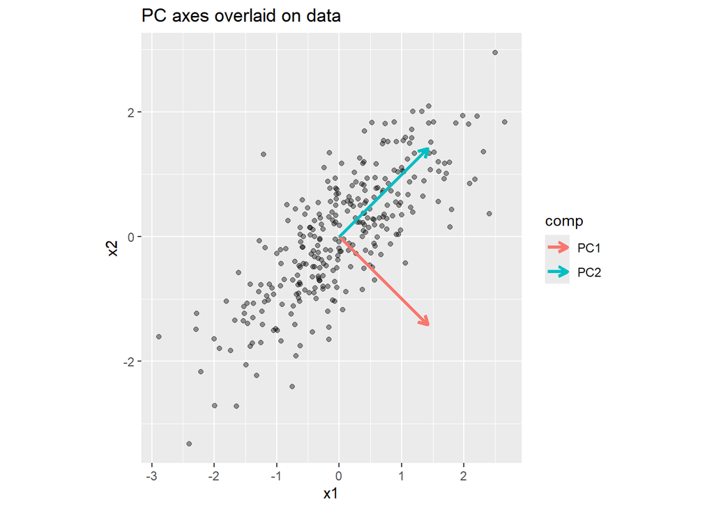

```r
loadings2 <- pca2$rotation
pc1 <- loadings2[,1]
pc2 <- loadings2[,2]
arrows_df <- data.frame(x = 0, y = 0, xend = pc1*2, yend = pc2*2, comp = c("PC1","PC2"))

ggplot(df2, aes(x = x1, y = x2)) +
geom_point(alpha = 0.4) +
geom_segment(data = arrows_df,
aes(x = x, y = y, xend = xend, yend = yend, color = comp),
arrow = arrow(length = unit(0.25, "cm")), size = 1.2) +
coord_equal() +
labs(title = "PC axes overlaid on data")
```

## 3.2 Example 2 — 3D data projected to 2D

Now, let’s move to three variables. Imagine we have data that actually lies on a flat surface (a plane) in three-dimensional space. It looks 3D, but most of the variation happens in just two dimensions.

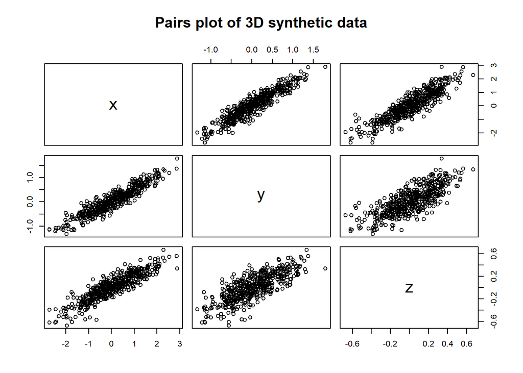

```r
set.seed(2)
n <- 500
x <- rnorm(n)
y <- 0.5 * x + rnorm(n, sd = 0.2)
z <- 0.3 * x - 0.2 * y + rnorm(n, sd = 0.1)
df3 <- data.frame(x = x, y = y, z = z)
pairs(df3, main = "Pairs plot of 3D synthetic data")
```

Let’s use PCA to find out whether this 3D data can really be simplified to 2D.

```r
pca3 <- prcomp(df3, center = TRUE, scale. = TRUE)
summary(pca3)
```

```
## Importance of components:
##                           PC1     PC2     PC3
## Standard deviation     1.6537 0.47894 0.18941
## Proportion of Variance 0.9116 0.07646 0.01196
## Cumulative Proportion  0.9116 0.98804 1.00000
```

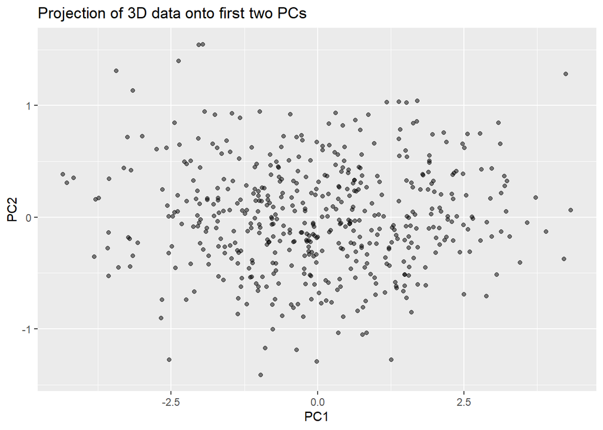

```r
scores3 <- as.data.frame(pca3$x)
ggplot(scores3, aes(x = PC1, y = PC2)) +
geom_point(alpha = 0.5) +
labs(title = "Projection of 3D data onto first two PCs")
```

Here PCA tells us that almost all the variation lies in the first two components — so we can describe the 3D data using just 2D without losing much information (Jolliffe (2002)). That’s the power of dimensionality reduction.

# 4 — Real dataset example: The Iris Flower

Now let’s move from synthetic to real data. The classic Iris dataset records the sepal and petal dimensions of 150 flowers from three species. We’ll see whether PCA can separate these species based purely on their measurements.

```r
data(iris)
iris_num <- iris %>% select(-Species)

pca_iris <- prcomp(iris_num, center = TRUE, scale. = TRUE)
summary(pca_iris)
```

```
## Importance of components:
##                           PC1    PC2     PC3     PC4
## Standard deviation     1.7084 0.9560 0.38309 0.14393
## Proportion of Variance 0.7296 0.2285 0.03669 0.00518
## Cumulative Proportion  0.7296 0.9581 0.99482 1.00000
```

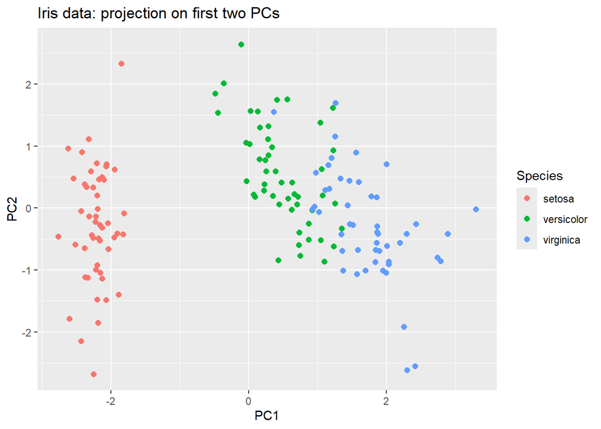

```r
scores_iris <- as.data.frame(pca_iris$x)
scores_iris$Species <- iris$Species

ggplot(scores_iris, aes(x = PC1, y = PC2, color = Species)) +
geom_point(size = 2) +
labs(title = "Iris data: projection on first two PCs")
```

Even though PCA doesn’t use the species labels (it’s unsupervised), you can still see clusters forming! That’s because flower species differ systematically in sepal and petal size, and PCA captures those differences naturally (James et al. (2013)).

We can also look at the loadings, which tell us how much each original feature contributes to each principal component.

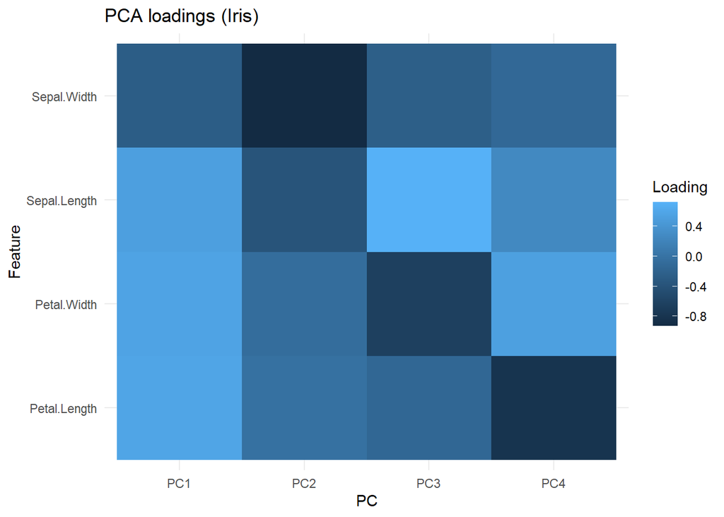

```r
loadings_iris <- as.data.frame(pca_iris$rotation)
loadings_iris$Feature <- rownames(loadings_iris)
loadings_long <- loadings_iris %>%
pivot_longer(cols = starts_with("PC"), names_to = "PC", values_to = "Loading")

ggplot(loadings_long, aes(x = PC, y = Feature, fill = Loading)) +
geom_tile() +
labs(title = "PCA loadings (Iris)") +
theme_minimal()
```

This heatmap shows which measurements matter most for each principal component — for example, petal length and width often dominate the first component.

# 5 — Explained variance and choosing components to Keep?

After we run PCA, we end up with several new axes — the principal components (PCs). But how do we decide which ones are worth keeping and which ones add very little new information?

Let’s build this up gradually.

### 5.1 What does “explained variance” mean?

Each principal component represents a direction in the data where there’s variation. Some directions show a lot of spread (the data varies widely there), while others show very little spread (the data barely changes along that axis).

The amount of variation captured by each component is called its explained variance. It tells us how much of the total “information” in the dataset that component accounts for.

If your data has 100% total variance across all variables, and:

PC1 captures 70% of it,

PC2 captures 20%,

PC3 captures 5%, then keeping just PC1 and PC2 would already explain 90% of the overall variability — a very good summary!

### 5.2 How do we measure it?

When PCA is performed, R computes eigenvalues (or equivalently, the squared singular values) for each component. These eigenvalues represent the amount of variance along each principal direction.

To find how much each component contributes, we divide each eigenvalue by the total sum of all eigenvalues. This gives the proportion of variance explained (PVE) for each component.

### 5.3 You can think of it like a pie chart:

Each slice = one principal component.

The size of the slice = how much of the total variation that component explains.

Each principal component explains a certain portion of the total variance. We can check this using the eigenvalues from our PCA model. A common way to decide how many components to keep is to plot the explained variance — known as a scree plot (Abdi & Williams (2010)).

### 5.4 Visualizing with a scree plot

A scree plot is a visual tool to decide how many components to keep. It shows the variance explained by each component, typically as bars or points.

```r
var_iris <- pca_iris$sdev^2
propvar_iris <- var_iris / sum(var_iris)
cumvar_iris <- cumsum(propvar_iris)
var_table_iris <- data.frame(
PC = paste0("PC", 1:length(var_iris)),
Variance = var_iris,
PropVar = propvar_iris,
CumVar = cumvar_iris
)

var_table_iris
```

```
##    PC   Variance     PropVar    CumVar
## 1 PC1 2.91849782 0.729624454 0.7296245
## 2 PC2 0.91403047 0.228507618 0.9581321
## 3 PC3 0.14675688 0.036689219 0.9948213
## 4 PC4 0.02071484 0.005178709 1.0000000
```

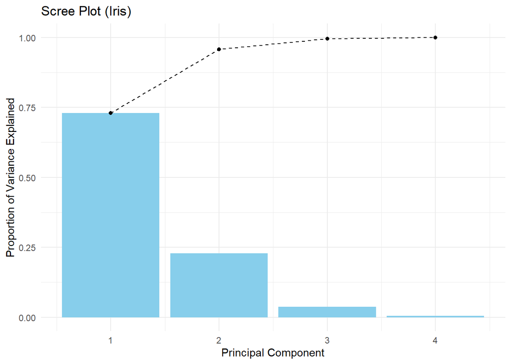

```r
ggplot(var_table_iris, aes(x = as.numeric(sub("PC","",PC)), y = PropVar)) +
geom_bar(stat = "identity", fill = "skyblue") +
geom_line(aes(y = CumVar), color = "black", linetype = "dashed") +
geom_point(aes(y = CumVar), color = "black") +
scale_x_continuous(breaks = 1:nrow(var_table_iris)) +
labs(x = "Principal Component",
y = "Proportion of Variance Explained",
title = "Scree Plot (Iris)") +
theme_minimal()
```

The Scree Plot above shows how much of the total variance in the Iris dataset is explained by each principal component (PC).

Each blue bar represents the proportion of variance explained by an individual component — basically, how much of the original “information” in the data that component captures. The dashed line connects the cumulative variance, which adds up the contribution of each component as we move along.

Here’s what we can see:

PC3 and PC4 contribute very little (just a few percent combined). These components mostly capture small fluctuations or noise rather than meaningful structure.

### 5.5 So how many components should we keep?

There’s no single “correct” answer, but we use practical rules to guide our choice.

Elbow (scree) rule: Look at the dashed line — it rises steeply at first (PC1 and PC2) and then flattens out. The point where the line starts to flatten is called the “elbow.” After that, adding more components doesn’t gain much extra variance. Here, the elbow clearly appears after PC2 — meaning anything beyond PC2 adds minimal value.

Interpretability: Keeping two components also makes visualization easier — we can plot the data in 2D (PC1 vs. PC2) and still retain almost all the information.

```r
var3 <- pca3$sdev^2
propvar3 <- var3 / sum(var3)
data.frame(PC = paste0('PC',1:length(var3)), PropVar = propvar3, CumVar = cumsum(propvar3))
```

```
##    PC    PropVar    CumVar
## 1 PC1 0.91157930 0.9115793
## 2 PC2 0.07646218 0.9880415
## 3 PC3 0.01195852 1.0000000
```

# 6 — Practical considerations

Now that we understand how PCA works, let’s talk about how to use it responsibly in real-world data analysis. PCA is powerful, but it makes a few assumptions — and breaking them can lead to misleading results. Here are the most important things to keep in mind:

### 6.1 Always center and scale your data

PCA is sensitive to the scale of your variables. If one feature (say, “income”) is measured in thousands, and another (say, “age”) is in years, the large numbers from income will dominate the analysis. This happens because PCA looks at variance — and larger numbers naturally have larger variances.

To make sure all variables contribute equally, we usually standardize each column: subtract its mean and divide by its standard deviation. In R, this happens automatically when you use prcomp(…, scale. = TRUE).

### 6.2 Handle missing data before applying PCA

PCA can’t handle missing values (NAs). If your dataset has gaps, fill them using methods like mean imputation, regression imputation, or more advanced tools like multiple imputation before running PCA. Otherwise, the computation of the covariance matrix breaks down.

### 6.3 Remember: PCA finds linear patterns

PCA assumes that the important relationships in your data are linear — that is, the data varies along straight-line directions. But if your data lies on a curved shape (like a spiral or a circle), PCA may not capture that structure effectively. In such cases, you might turn to nonlinear dimensionality reduction methods such as Kernel PCA or t-SNE, which can handle curved relationships better (Abdi & Williams (2010)).

### 6.4 Interpret the loadings carefully

The loadings tell you how each original variable contributes to each principal component. They help you answer questions like:

“Which features drive most of the variation in PC1?”

“What combination of variables defines PC2?”

Examining loadings gives meaning to your new axes — it’s how you interpret what each principal component represents in practical terms.

# 7 — Reconstructing and measuring loss

PCA isn’t just for reducing dimensions — it also helps us measure how much information we lose when we simplify the data.

Think of PCA like summarizing a long story into a few sentences. The more sentences you keep, the closer you stay to the original meaning. Here, those “sentences” are the principal components.

After performing PCA, we can rebuild an approximation of the original dataset using only the first few components. If we keep all of them, the reconstruction is perfect; if we keep just a few, we get a simpler version that’s close but not exact.

Let’s test this on our Iris data.

```r
X <- scale(iris_num, center = TRUE, scale = TRUE)
U <- pca_iris$rotation
scores <- pca_iris$x

reconstruct_k <- function(k){
Xhat <- scores[,1:k, drop=FALSE] %*% t(U[,1:k, drop=FALSE])
center <- attr(X, "scaled:center")
scalev <- attr(X, "scaled:scale")
Xhat_unscaled <- sweep(Xhat, 2, scalev, FUN = "*")
Xhat_unscaled <- sweep(Xhat_unscaled, 2, center, FUN = "+")
return(Xhat_unscaled)
}

mse <- sapply(1:4, function(k){
mean((as.matrix(iris_num) - reconstruct_k(k))^2)
})
data.frame(k = 1:4, MSE = mse)
```

```
##   k          MSE
## 1 1 9.548351e-02
## 2 2 3.553731e-02
## 3 3 1.137197e-02
## 4 4 2.287247e-31
```

The table shows the mean squared error (MSE) — a measure of how close the reconstructed data is to the original. As we keep more components, the reconstruction becomes more accurate (the MSE gets smaller).

With 1 or 2 components, we capture the main structure but lose small details.

With all components, we perfectly reconstruct the original data.

This pattern is what makes PCA so useful for data compression: you can represent most of the dataset’s information using only a few principal components instead of every original feature.

In the Iris example, using just the first two components retains over 95% of the variance — a huge reduction from four variables to two dimensions, with almost no loss of meaning (James et al. (2013)).

# 8 - Conclusion

In this tutorial, we explored Principal Component Analysis (PCA) — not just as a mathematical technique, but as a powerful way to see structure in data.

We began with intuition: PCA finds the directions where data varies the most and uses them to create new, uncorrelated variables called principal components. Through synthetic examples, we saw how PCA can take complex, correlated data and express it more simply. Then, using real-world datasets like Iris, we discovered that PCA can reveal hidden patterns — such as natural groupings — even without using labels.

We also learned that:

Each principal component explains a portion of the total variance, helping us decide how many to keep.

The first few components often capture most of the information, allowing us to simplify our data without losing meaning.

Centering, scaling, and handling missing data are essential before applying PCA.

PCA’s “loadings” help interpret what each component actually represents in real-world terms.

Finally, we explored how PCA can reconstruct the data and measure how much information is lost when we reduce dimensions — showing that PCA is not just about compression, but also about understanding what matters most in your data.

In essence:

PCA is a lens. It lets us look at data from a new angle — one that highlights patterns, simplifies complexity, and reveals relationships that might otherwise stay hidden.

By mastering PCA, you’ve added a fundamental data analysis skill to your toolkit — one that bridges statistics, machine learning, and data visualization.

# 9 — References

- James, G., Witten, D., Hastie, T., & Tibshirani, R. (2013). *An Introduction to Statistical Learning*. https://www.statlearning.com/
- Jolliffe, I. T. (2002). *Principal Component Analysis*. Springer.
- Abdi, H., & Williams, L. J. (2010). *Wiley Interdisciplinary Reviews: Computational Statistics*, 2(4), 433–459.

Abdi, H., & Williams, L. J. (2010). Principal component analysis. *Wiley Interdisciplinary Reviews: Computational Statistics*, *2*(4), 433–459.

James, G., Witten, D., Hastie, T., & Tibshirani, R. (2013). *An introduction to statistical learning*. Springer. https://www.statlearning.com/

Jolliffe, I. T. (2002). *Principal component analysis* (2nd ed.). Springer.